# Exercise 15-1: More analysis of the Curry data

## Get the data and Imported necessary Modules

```python
import pandas as pd
import seaborn as sns
import json
import matplotlib.pyplot as plt
```

```python
# I have load the json Dataseet into a dictonary and build a Dataframe named shots.
with open('C:/Users/Khush/Python Analysis/shots for assignment.json') as jsonData:
    shots = json.load(jsonData)
columnHeaders = [x.lower() for x in shots['resultSets'][0]['headers']]
rows = shots['resultSets'][0]['rowSet']
shots = pd.DataFrame(data=rows, columns=columnHeaders)
```

```python
# 4) Display the first five rows
print("First five rows of the DataFrame:")
shots.head()
```

```
First five rows of the DataFrame:
```

|  | grid_type | game_id | game_event_id | player_id | player_name | team_id | team_name | period | minutes_remaining | seconds_remaining | ... | shot_zone_area | shot_zone_range | shot_distance | loc_x | loc_y | shot_attempted_flag | shot_made_flag | game_date | htm | vtm |
| --- | --- | --- | --- | --- | --- | --- | --- | --- | --- | --- | --- | --- | --- | --- | --- | --- | --- | --- | --- | --- | --- |
| 0 | Shot Chart Detail | 0020900015 | 4 | 201939 | Stephen Curry | 1610612744 | Golden State Warriors | 1 | 11 | 25 | ... | Right Side Center(RC) | 24+ ft. | 26 | 99 | 249 | 1 | 0 | 20091028 | GSW | HOU |
| 1 | Shot Chart Detail | 0020900015 | 17 | 201939 | Stephen Curry | 1610612744 | Golden State Warriors | 1 | 9 | 31 | ... | Left Side Center(LC) | 16-24 ft. | 18 | -122 | 145 | 1 | 1 | 20091028 | GSW | HOU |
| 2 | Shot Chart Detail | 0020900015 | 53 | 201939 | Stephen Curry | 1610612744 | Golden State Warriors | 1 | 6 | 2 | ... | Center(C) | 8-16 ft. | 14 | -60 | 129 | 1 | 0 | 20091028 | GSW | HOU |
| 3 | Shot Chart Detail | 0020900015 | 141 | 201939 | Stephen Curry | 1610612744 | Golden State Warriors | 2 | 9 | 49 | ... | Left Side(L) | 16-24 ft. | 19 | -172 | 82 | 1 | 0 | 20091028 | GSW | HOU |
| 4 | Shot Chart Detail | 0020900015 | 249 | 201939 | Stephen Curry | 1610612744 | Golden State Warriors | 2 | 2 | 19 | ... | Left Side Center(LC) | 16-24 ft. | 16 | -68 | 148 | 1 | 0 | 20091028 | GSW | HOU |

5 rows × 24 columns

## Clean the data

```python
#5. Run the cell that drops some of the unneeded columns.
shots = shots.drop(columns=['grid_type','game_event_id','player_id','player_name',
                            'team_id','team_name','minutes_remaining','seconds_remaining',
                            'htm','vtm'])
```

```python
#6. Displaying the first five rows of the shots DataFrame.
shots.head()
```

|  | game_id | period | event_type | action_type | shot_type | shot_zone_basic | shot_zone_area | shot_zone_range | shot_distance | loc_x | loc_y | shot_attempted_flag | shot_made_flag | game_date |
| --- | --- | --- | --- | --- | --- | --- | --- | --- | --- | --- | --- | --- | --- | --- |
| 0 | 0020900015 | 1 | Missed Shot | Jump Shot | 3PT Field Goal | Above the Break 3 | Right Side Center(RC) | 24+ ft. | 26 | 99 | 249 | 1 | 0 | 20091028 |
| 1 | 0020900015 | 1 | Made Shot | Step Back Jump shot | 2PT Field Goal | Mid-Range | Left Side Center(LC) | 16-24 ft. | 18 | -122 | 145 | 1 | 1 | 20091028 |
| 2 | 0020900015 | 1 | Missed Shot | Jump Shot | 2PT Field Goal | In The Paint (Non-RA) | Center(C) | 8-16 ft. | 14 | -60 | 129 | 1 | 0 | 20091028 |
| 3 | 0020900015 | 2 | Missed Shot | Jump Shot | 2PT Field Goal | Mid-Range | Left Side(L) | 16-24 ft. | 19 | -172 | 82 | 1 | 0 | 20091028 |
| 4 | 0020900015 | 2 | Missed Shot | Jump Shot | 2PT Field Goal | Mid-Range | Left Side Center(LC) | 16-24 ft. | 16 | -68 | 148 | 1 | 0 | 20091028 |

```python
# 7 Display the value counts for the 'period' column
# In this Filtering with ~shots_df['period'].isin([5, 6]) removes rows where the period column has values 5 or 6.
print("\nValue counts for the 'period' column:")
print(shots['period'].value_counts())
```

```
Value counts for the 'period' column:
period
3    3541
1    3501
2    2502
4    2209
5      90
6       3
Name: count, dtype: int64
```

```python
#7. Drop rows where 'period' is 5 or 6
shots = shots[~shots['period'].isin([5, 6])]
```

```python
# display the first five rows
shots.head()
```

|  | game_id | period | event_type | action_type | shot_type | shot_zone_basic | shot_zone_area | shot_zone_range | shot_distance | loc_x | loc_y | shot_attempted_flag | shot_made_flag | game_date |
| --- | --- | --- | --- | --- | --- | --- | --- | --- | --- | --- | --- | --- | --- | --- |
| 0 | 0020900015 | 1 | Missed Shot | Jump Shot | 3PT Field Goal | Above the Break 3 | Right Side Center(RC) | 24+ ft. | 26 | 99 | 249 | 1 | 0 | 20091028 |
| 1 | 0020900015 | 1 | Made Shot | Step Back Jump shot | 2PT Field Goal | Mid-Range | Left Side Center(LC) | 16-24 ft. | 18 | -122 | 145 | 1 | 1 | 20091028 |
| 2 | 0020900015 | 1 | Missed Shot | Jump Shot | 2PT Field Goal | In The Paint (Non-RA) | Center(C) | 8-16 ft. | 14 | -60 | 129 | 1 | 0 | 20091028 |
| 3 | 0020900015 | 2 | Missed Shot | Jump Shot | 2PT Field Goal | Mid-Range | Left Side(L) | 16-24 ft. | 19 | -172 | 82 | 1 | 0 | 20091028 |
| 4 | 0020900015 | 2 | Missed Shot | Jump Shot | 2PT Field Goal | Mid-Range | Left Side Center(LC) | 16-24 ft. | 16 | -68 | 148 | 1 | 0 | 20091028 |

# Prepare and analyze the data

```python
# 8.Display the number of unique values for the 'action_type' column
print("\nNumber of unique values in the 'action_type' column:")
print(shots['action_type'].nunique())
```

```
Number of unique values in the 'action_type' column:
51
```

```python
# 8. Display the value counts for the action_type column
print(shots['action_type'].value_counts())
```

```
action_type
Jump Shot                             5802
Pullup Jump shot                      1694
Step Back Jump shot                    755
Driving Layup Shot                     635
Layup Shot                             537
Floating Jump shot                     387
Driving Finger Roll Layup Shot         324
Running Jump Shot                      209
Driving Reverse Layup Shot             165
Running Layup Shot                     131
Cutting Layup Shot                     119
Jump Bank Shot                         108
Reverse Layup Shot                     102
Fadeaway Jump Shot                      90
Turnaround Jump Shot                    89
Driving Floating Jump Shot              83
Running Bank shot                       61
Running Finger Roll Layup Shot          51
Running Pull-Up Jump Shot               44
Finger Roll Layup Shot                  36
Driving Bank shot                       36
Driving Floating Bank Jump Shot         34
Running Reverse Layup Shot              33
Driving Jump shot                       32
Cutting Finger Roll Layup Shot          28
Turnaround Fadeaway shot                26
Pullup Bank shot                        20
Turnaround Bank shot                    20
Putback Layup Shot                      11
Hook Shot                               10
Running Hook Shot                       10
Driving Hook Shot                        9
Slam Dunk Shot                           7
Driving Dunk Shot                        7
Tip Shot                                 7
Tip Layup Shot                           6
Running Dunk Shot                        6
Dunk Shot                                5
Fadeaway Bank shot                       4
Turnaround Fadeaway Bank Jump Shot       3
Step Back Bank Jump Shot                 3
Turnaround Hook Shot                     3
Driving Slam Dunk Shot                   2
Jump Hook Shot                           2
Cutting Dunk Shot                        1
Driving Bank Hook Shot                   1
Alley Oop Layup shot                     1
Running Bank Hook Shot                   1
Hook Bank Shot                           1
Running Slam Dunk Shot                   1
Putback Dunk Shot                        1
Name: count, dtype: int64
```

## Data Districution of Action-Type

- I can see Jump Shots and Layups are the most common, with Jump Shots dominating (5,802 attempts).
- More specialized shots like Hook Shots and Dunks are rare, used only in specific situations or by certain players.

```python
#9. Add substrings such as “Jump” and “Layup” to the list of common substrings that identify each action type.
# Then, continue to add substrings and to test this code until you’re sure that it provides all the values for the action_type column.
# STEPS:
# pick common substring from the value counts
# add common substrings to list
# query the shots for the actions until empty

commonSubstrings = ['Jump', 'Layup','Hook','Bank','Tip','Dunk','Fadeaway']
# get a list of action_type values that contain the words from the commonSubstrings
actions = shots[shots.action_type.str.contains('|'.join(commonSubstrings))].action_type.to_list()
shots.query('action_type not in @actions').action_type
```

```
Series([], Name: action_type, dtype: object)
```

```python
print("Num of common substrings that cover all rows: ", len(commonSubstrings))
```

```
Num of common substrings that cover all rows:  7
```

From the list of common substring we see that only 7 commonsubstrings cover all the rows in the dataset and these common substrings are `['Jump', 'Layup','Hook','Bank','Tip','Dunk','Fadeaway']`

#### Helper Function to extract CommonSubstring

`get_label()` extracts common substring from the action_type of a given row.

This function checks the action_type of a row against a predefined list of common substrings and returns the first matching substring found. If no match is found, it returns an empty string.

**Input**: row A pandas Series representing a single row from a DataFrame, which must include the 'action_type' field.

**Output** : A string representing the first common substring found in the action_type; returns an empty string if no common substring is present.

```python
#10. define the getLabel() function here
def get_label(row):
    for commonSubstring in commonSubstrings:
        if commonSubstring in row.action_type:
            return commonSubstring
    return ""
```

#### Categorize shot_type

- The code iterates over each row in the `shots` DataFrame using `iterrows()`, applying the `get_label()` function to extract a common substring from the `action_type` of each row.
- It assigns the resulting substring to a new column named `shot_type` in the `shots` DataFrame, allowing for easy categorization of each shot based on the identified substring.

```python
# 11. apply the getLabel() function and assign the results to a column named shot_type
# Loop through each row using iterrows()
for index, row in shots.iterrows():
    # Access individual elements by column name
    result = get_label(row)
    # Assign result to the 'shot_type' column at the current index
    shots.at[index, 'shot_type'] = result
shots.head()
```

|  | game_id | period | event_type | action_type | shot_type | shot_zone_basic | shot_zone_area | shot_zone_range | shot_distance | loc_x | loc_y | shot_attempted_flag | shot_made_flag | game_date |
| --- | --- | --- | --- | --- | --- | --- | --- | --- | --- | --- | --- | --- | --- | --- |
| 0 | 0020900015 | 1 | Missed Shot | Jump Shot | Jump | Above the Break 3 | Right Side Center(RC) | 24+ ft. | 26 | 99 | 249 | 1 | 0 | 20091028 |
| 1 | 0020900015 | 1 | Made Shot | Step Back Jump shot | Jump | Mid-Range | Left Side Center(LC) | 16-24 ft. | 18 | -122 | 145 | 1 | 1 | 20091028 |
| 2 | 0020900015 | 1 | Missed Shot | Jump Shot | Jump | In The Paint (Non-RA) | Center(C) | 8-16 ft. | 14 | -60 | 129 | 1 | 0 | 20091028 |
| 3 | 0020900015 | 2 | Missed Shot | Jump Shot | Jump | Mid-Range | Left Side(L) | 16-24 ft. | 19 | -172 | 82 | 1 | 0 | 20091028 |
| 4 | 0020900015 | 2 | Missed Shot | Jump Shot | Jump | Mid-Range | Left Side Center(LC) | 16-24 ft. | 16 | -68 | 148 | 1 | 0 | 20091028 |

## Plot the data

The code creates a count plot of the `shot_type` column in the `shots` DataFrame, displaying the frequency of each shot type. It includes labeled axes and a title for clarity, with x-tick labels rotated for better readability before displaying the plot. I see that the JUMP is most used shot type in this plot.

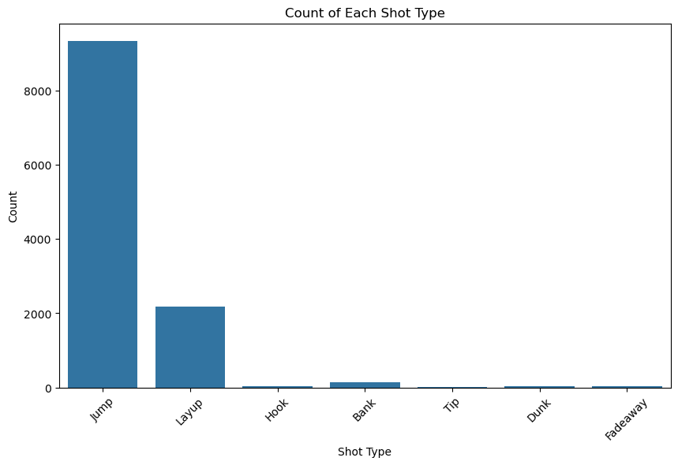

```python
#12. Create a count plot for the 'shot_type' column
plt.figure(figsize=(10, 6))
sns.countplot(data=shots, x='shot_type')

# Add labels and title for clarity
plt.xlabel("Shot Type")
plt.ylabel("Count")
plt.title("Count of Each Shot Type")
plt.xticks(rotation=45)  # Rotate x labels if needed
plt.show()
```

```python
# SOURCE: http://savvastjortjoglou.com/nba-shot-sharts.html
from matplotlib.patches import Circle, Rectangle, Arc

def draw_court(ax=None, color='black', lw=2, outer_lines=False):
    # If an axes object isn't provided to plot onto, just get current one
    if ax is None:
        ax = plt.gca()

    # Create the various parts of an NBA basketball court

    # Create the basketball hoop
    # Diameter of a hoop is 18" so it has a radius of 9", which is a value
    # 7.5 in our coordinate system
    hoop = Circle((0, 0), radius=7.5, linewidth=lw, color=color, fill=False)

    # Create backboard
    backboard = Rectangle((-30, -7.5), 60, -1, linewidth=lw, color=color)

    # The paint
    # Create the outer box 0f the paint, width=16ft, height=19ft
    outer_box = Rectangle((-80, -47.5), 160, 190, linewidth=lw, color=color,
                          fill=False)
    # Create the inner box of the paint, widt=12ft, height=19ft
    inner_box = Rectangle((-60, -47.5), 120, 190, linewidth=lw, color=color,
                          fill=False)

    # Create free throw top arc
    top_free_throw = Arc((0, 142.5), 120, 120, theta1=0, theta2=180,
                         linewidth=lw, color=color, fill=False)
    # Create free throw bottom arc
    bottom_free_throw = Arc((0, 142.5), 120, 120, theta1=180, theta2=0,
                            linewidth=lw, color=color, linestyle='dashed')
    # Restricted Zone, it is an arc with 4ft radius from center of the hoop
    restricted = Arc((0, 0), 80, 80, theta1=0, theta2=180, linewidth=lw,
                     color=color)

    # Three point line
    # Create the side 3pt lines, they are 14ft long before they begin to arc
    corner_three_a = Rectangle((-220, -47.5), 0, 140, linewidth=lw,
                               color=color)
    corner_three_b = Rectangle((220, -47.5), 0, 140, linewidth=lw, color=color)
    # 3pt arc - center of arc will be the hoop, arc is 23'9" away from hoop
    # I just played around with the theta values until they lined up with the
    # threes
    three_arc = Arc((0, 0), 475, 475, theta1=22, theta2=158, linewidth=lw,
                    color=color)

    # Center Court
    center_outer_arc = Arc((0, 422.5), 120, 120, theta1=180, theta2=0,
                           linewidth=lw, color=color)
    center_inner_arc = Arc((0, 422.5), 40, 40, theta1=180, theta2=0,
                           linewidth=lw, color=color)

    # List of the court elements to be plotted onto the axes
    court_elements = [hoop, backboard, outer_box, inner_box, top_free_throw,
                      bottom_free_throw, restricted, corner_three_a,
                      corner_three_b, three_arc, center_outer_arc,
                      center_inner_arc]

    if outer_lines:
        # Draw the half court line, baseline and side out bound lines
        outer_lines = Rectangle((-250, -47.5), 500, 470, linewidth=lw,
                                color=color, fill=False)
        court_elements.append(outer_lines)

    # Add the court elements onto the axes
    for element in court_elements:
        ax.add_patch(element)

    return ax
```

#### KDE Plot to see the Distribution of shot type

- **Data Filtering**: The code filters the `shots` DataFrame to include only the rows where the `shot_type` is either "Jump" or "Layup," creating a new DataFrame called `shots_filtered`.
- **KDE Plot Creation**: A Kernel Density Estimate (KDE) plot is created using `sns.displot()`, plotting the x-coordinates (`loc_x`) and y-coordinates (`loc_y`) of the shots, with separate subplots for each shot type ("Jump" and "Layup"). The `fill=True` parameter fills the density areas, and the dimensions of the subplots are set.
- **Court Overlay**: The `draw_court()` function is called for each subplot to overlay a basketball court design, providing context for the shot locations.
- **Plot Display**: Finally, `plt.show()` is called to display the KDE plots, visually representing the distribution of shots on the court for each shot type.

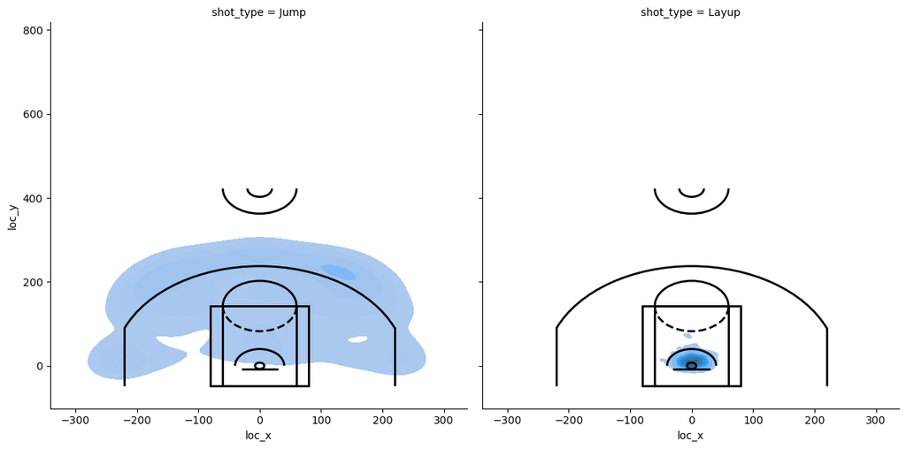

```python
#13. create a KDE plot that plots the distribution of the shots for each shot type
# and displays them on the court
# Filter the data for 'Jump' and 'Layup' shot types
shots_filtered = shots[shots['shot_type'].isin(['Jump', 'Layup'])]
# Create the KDE plot with subplots for each shot type
g = sns.displot(
    data=shots_filtered,
    x='loc_x', y='loc_y',
    col='shot_type',  # Creates a subplot for each shot type
    kind='kde',
    fill=True,
    height=6,
    aspect=1
)
# Overlay the court on each subplot
for ax in g.axes.flat:
    draw_court(ax)

# Display the plot
plt.show()
```

#### Explanation of Plot

The plot shows that the distribution of `Jump` shots is spread out across the court, while `Layup` shots are concentrated near the basket. This aligns with what we would typically expect in a basketball game.